# The Secret of the Primitive Accumulation?

Carlos E. Tavarez Martinez

```r
#load required libraries here using library() command
library(ggplot2)
library(dplyr)
```

## Background

Modern economic growth begins with the industrial revolution in Britain and the rest of northwestern Europe around 1800. But before that, those countries were already some of the most prosperous parts of the world, which is part of why the industrial revolution happened there. Explaining that pre-industrial growth, sometimes called “primitive accumulation”, is therefore an important problem in economics and world history.

We will look at a model, and the accompanying data, for one of the leading contemporary theories of this growth. The theory, in brief, is that the key factor driving this early growth was trade across the Atlantic, involving New World plantations (for, e.g., sugar), slaves, and imperial ventures in Africa and Asia. Countries which could participate in these Atlantic trades grew richer than others. The theory goes on that countries which started with relatively free institutions that protected private property were able to take more advantage of the Atlantic trade than countries with more absolutist institutions (and that merchants growing rich from the trade encouraged even less absolutist institutions later on). The scholars who have elaborated this theory have gathered a data set of the relevant variables, which is available as RAJ.csv. This also contains a number of variables which are intended as controls, because they are important to rival theories. Each row in the data represents a particular country in a particular year. The countries are limited to Europe and Asia. As is usual for real data, some variables are missing for some rows.

1. country
2. year
3. urbanization An estimate of the fraction of the population living in cities and towns.
4. population The total population of the country (in thousands of people)
5. coastToArea The ratio of the country’s Atlantic coast-line (in miles) to its total land area (in square miles).
6. execConstr A rating of how constrained the executive branch of the country’s government was, on a seven-point ordinal scale from 1 (least constrained) to 7 (most constrained).
7. initialConstr Rating of how constrained the executive branch of the country’s government was “initially”, averaging ratings for 1400 and 1500
8. atlTrade An index of the volume of the trade carried over the Atlantic, across all countries.
9. westernEurope An indicator for whether the country is part of western Europe.
10. easternEurope An indicator for whether the country is part of eastern Europe.
11. wars The number of wars the country engaged in, per year, over the period.
12. protestant Whether the country’s inhabitants are primarily Protestant Christians.
13. roman Whether the country was part of the Roman Empire.
14. gdppc An estimate of per-capita GDP, in current dollars. (This is known to be very imprecise.)

Urbanization is being used here as a proxy for the over-all level of economic development. The favored model of the scholars who proposed this is that the level of urbanization of country i in year t is

$$(1)\;\;\;\;\;u_{it} = d_{t} + δ_{i} + α_{t}W_{i}M_{t} + βA_{t} P_{i} + γ_{t}C_{i}M_{t} + ηA_{t} P_{i}C_{i} + ε_{it}$$

where $d_{t}$ and $δ_{i}$ are “fixed effects” for year and country (respectively); $W_{i}$ is an indicator for country $i$ being in western Europe; $A_{t}$ is the index of Atlantic trade in year $t$; Pi is country i’s potential for Atlantic trade, measured by its coastline-to-area ratio; $C_{i}$ is the country’s “initial” level constraint on the executive, in 1400–1500; $M_{t}$ is an indicator variable, 1 if the year is ≥ 1500 and 0 earlier; and $ε_{it}$ combines noise and measurement error

## Data-Analysis

#### Data Setup

The data frame dat is missing the $M_{t}$ variable, to concise the proposed formula, a new column was created for this variable. Recall that $M_{t}$ is 1 if the year is ≥ 1500 and 0 if earlier.

```r
# Data as a data frame
dat <- read.csv("1RAJ.csv", sep=",")

print(summary(dat))
```

```
##      country         year       urbanization       population
##  Albania :  8   Min.   :1300   Min.   :0.00000   Min.   :   100
##  Austria :  8   1st Qu.:1475   1st Qu.:0.04225   1st Qu.:  1188
##  Belgium :  8   Median :1650   Median :0.07943   Median :  2500
##  Bulgaria:  8   Mean   :1612   Mean   :0.10308   Mean   : 17638
##  China   :  8   3rd Qu.:1762   3rd Qu.:0.13090   3rd Qu.:  9000
##  Czech   :  8   Max.   :1850   Max.   :0.48125   Max.   :420000
##  (Other) :176                  NA's   :16        NA's   :16
##   coastToArea         execConstr   initialConstr    atlTrade
##  Min.   :0.000000   Min.   :1.00   Min.   :1.0   Min.   :0.09531
##  1st Qu.:0.000000   1st Qu.:1.00   1st Qu.:1.0   1st Qu.:2.82867
##  Median :0.000000   Median :1.00   Median :1.5   Median :4.83817
##  Mean   :0.005289   Mean   :1.92   Mean   :1.7   Mean   :4.48609
##  3rd Qu.:0.004287   3rd Qu.:3.00   3rd Qu.:2.0   3rd Qu.:6.35474
##  Max.   :0.051445   Max.   :7.00   Max.   :3.0   Max.   :7.83795
##                     NA's   :24     NA's   :24
##  westernEurope    easternEurope      war           protestant
##  Min.   :0.0000   Min.   :0.0   Min.   :0.0000   Min.   :0.00
##  1st Qu.:0.0000   1st Qu.:0.0   1st Qu.:0.0000   1st Qu.:0.00
##  Median :1.0000   Median :0.0   Median :0.2200   Median :0.00
##  Mean   :0.5357   Mean   :0.4   Mean   :0.3817   Mean   :0.25
##  3rd Qu.:1.0000   3rd Qu.:1.0   3rd Qu.:0.6400   3rd Qu.:0.25
##  Max.   :1.0000   Max.   :1.0   Max.   :2.2200   Max.   :1.00
##                   NA's   :24    NA's   :48       NA's   :24
##      Roman          gdppc
##  Min.   :0.00   Min.   : 453.0
##  1st Qu.:0.00   1st Qu.: 569.0
##  Median :0.00   Median : 761.0
##  Mean   :0.25   Mean   : 914.7
##  3rd Qu.:0.25   3rd Qu.:1047.5
##  Max.   :1.00   Max.   :3487.0
##                 NA's   :84
```

```r
# Addition of column for the M_t indicator
datos <- data.frame(mutate(dat, m_t = ifelse(dat$year >= 1500, 1, 0)))

print(summary(datos))
```

```
##      country         year       urbanization       population
##  Albania :  8   Min.   :1300   Min.   :0.00000   Min.   :   100
##  Austria :  8   1st Qu.:1475   1st Qu.:0.04225   1st Qu.:  1188
##  Belgium :  8   Median :1650   Median :0.07943   Median :  2500
##  Bulgaria:  8   Mean   :1612   Mean   :0.10308   Mean   : 17638
##  China   :  8   3rd Qu.:1762   3rd Qu.:0.13090   3rd Qu.:  9000
##  Czech   :  8   Max.   :1850   Max.   :0.48125   Max.   :420000
##  (Other) :176                  NA's   :16        NA's   :16
##   coastToArea         execConstr   initialConstr    atlTrade
##  Min.   :0.000000   Min.   :1.00   Min.   :1.0   Min.   :0.09531
##  1st Qu.:0.000000   1st Qu.:1.00   1st Qu.:1.0   1st Qu.:2.82867
##  Median :0.000000   Median :1.00   Median :1.5   Median :4.83817
##  Mean   :0.005289   Mean   :1.92   Mean   :1.7   Mean   :4.48609
##  3rd Qu.:0.004287   3rd Qu.:3.00   3rd Qu.:2.0   3rd Qu.:6.35474
##  Max.   :0.051445   Max.   :7.00   Max.   :3.0   Max.   :7.83795
##                     NA's   :24     NA's   :24
##  westernEurope    easternEurope      war           protestant
##  Min.   :0.0000   Min.   :0.0   Min.   :0.0000   Min.   :0.00
##  1st Qu.:0.0000   1st Qu.:0.0   1st Qu.:0.0000   1st Qu.:0.00
##  Median :1.0000   Median :0.0   Median :0.2200   Median :0.00
##  Mean   :0.5357   Mean   :0.4   Mean   :0.3817   Mean   :0.25
##  3rd Qu.:1.0000   3rd Qu.:1.0   3rd Qu.:0.6400   3rd Qu.:0.25
##  Max.   :1.0000   Max.   :1.0   Max.   :2.2200   Max.   :1.00
##                   NA's   :24    NA's   :48       NA's   :24
##      Roman          gdppc             m_t
##  Min.   :0.00   Min.   : 453.0   Min.   :0.00
##  1st Qu.:0.00   1st Qu.: 569.0   1st Qu.:0.75
##  Median :0.00   Median : 761.0   Median :1.00
##  Mean   :0.25   Mean   : 914.7   Mean   :0.75
##  3rd Qu.:0.25   3rd Qu.:1047.5   3rd Qu.:1.00
##  Max.   :1.00   Max.   :3487.0   Max.   :1.00
##                 NA's   :84
```

#### Model Building

To build the model, I assumed that the variables $(α_{t}, γ_{t})$ are hold constants values and not as a time dependent variables:
$$(R-formula)\;\;\;\;\;u_{it} = d_{t} + δ_{i} + 0.008763(W_{i}M_{t}) - 0.483881(A_{t} P_{i}) - 0.005191(C_{i}M_{t}) + 0.456289(A_{t}P_{i}C_{i}) + ε_{it}$$

```r
# This code generates the linear model for question a).
f_model <- lm(urbanization ~ factor(year) + factor(country) + I(westernEurope*m_t) + I(coastToArea*atlTrade) + I(initialConstr*m_t) + I(coastToArea*atlTrade*initialConstr) + 0, datos)

f_m <- summary(f_model)
print(f_m)
```

```
##
## Call:
## lm(formula = urbanization ~ factor(year) + factor(country) +
##     I(westernEurope * m_t) + I(coastToArea * atlTrade) + I(initialConstr *
##     m_t) + I(coastToArea * atlTrade * initialConstr) + 0, data = datos)
##
## Residuals:
##       Min        1Q    Median        3Q       Max
## -0.106616 -0.019625 -0.002212  0.015887  0.231067
##
## Coefficients:
##                                            Estimate Std. Error t value
## factor(year)1300                           0.113030   0.017984   6.285
## factor(year)1400                           0.116616   0.017997   6.480
## factor(year)1500                           0.125081   0.020162   6.204
## factor(year)1600                           0.133599   0.020056   6.661
## factor(year)1700                           0.144230   0.020035   7.199
## factor(year)1750                           0.143636   0.020018   7.175
## factor(year)1800                           0.176810   0.020021   8.831
## factor(year)1850                           0.179475   0.020053   8.950
## factor(country)Austria                    -0.073154   0.023498  -3.113
## factor(country)Belgium                     0.129576   0.025877   5.007
## factor(country)Bulgaria                   -0.029693   0.020379  -1.457
## factor(country)Czech                      -0.092694   0.021762  -4.260
## factor(country)Denmark                    -0.106519   0.026678  -3.993
## factor(country)England                    -0.127746   0.032428  -3.939
## factor(country)Finland                    -0.120149   0.023498  -5.113
## factor(country)France                     -0.043161   0.023436  -1.842
## factor(country)Germany                    -0.047202   0.023415  -2.016
## factor(country)Greece                     -0.065387   0.020379  -3.209
## factor(country)Hungary                    -0.053603   0.021762  -2.463
## factor(country)Ireland                    -0.140387   0.024807  -5.659
## factor(country)Italy                       0.068664   0.026159   2.625
## factor(country)Netherlands                 0.100580   0.026635   3.776
## factor(country)Norway                     -0.101617   0.023775  -4.274
## factor(country)Poland                     -0.084909   0.025465  -3.334
## factor(country)Portugal                   -0.025919   0.030852  -0.840
## factor(country)Romania                    -0.089171   0.020379  -4.376
## factor(country)Russia                     -0.095664   0.020379  -4.694
## factor(country)Serbia                     -0.084803   0.020379  -4.161
```

[output cut: 35 more lines]

```
## factor(country)Serbia                     5.20e-05 ***
## factor(country)Spain                      0.218950
## factor(country)Sweden                     0.000120 ***
## factor(country)Switzerland                0.004831 **
## I(westernEurope * m_t)                    0.575122
## I(coastToArea * atlTrade)                 0.463906
## I(initialConstr * m_t)                    0.610837
## I(coastToArea * atlTrade * initialConstr) 0.096786 .
## ---
## Signif. codes:  0 '***' 0.001 '**' 0.01 '*' 0.05 '.' 0.1 ' ' 1
##
## Residual standard error: 0.04076 on 157 degrees of freedom
##   (32 observations deleted due to missingness)
## Multiple R-squared:  0.9253, Adjusted R-squared:  0.9086
## F-statistic: 55.54 on 35 and 157 DF,  p-value: < 2.2e-16
```

```r
# This code generates the confidence interval for each coefficient.
confint(f_model, level = 0.95)
```

```
##                                                 2.5 %        97.5 %
## factor(year)1300                           0.07750878  0.1485513220
## factor(year)1400                           0.08106829  0.1521638732
## factor(year)1500                           0.08525756  0.1649039902
## factor(year)1600                           0.09398414  0.1732142124
## factor(year)1700                           0.10465689  0.1838035726
## factor(year)1750                           0.10409733  0.1831749731
## factor(year)1800                           0.13726409  0.2163554151
## factor(year)1850                           0.13986696  0.2190838868
## factor(country)Austria                    -0.11956746 -0.0267399352
## factor(country)Belgium                     0.07846459  0.1806878306
## factor(country)Bulgaria                   -0.06994415  0.0105587442
## factor(country)Czech                      -0.13567812 -0.0497107660
## factor(country)Denmark                    -0.15921328 -0.0538256153
## factor(country)England                    -0.19179705 -0.0636952426
## factor(country)Finland                    -0.16656235 -0.0737348215
## factor(country)France                     -0.08945214  0.0031302451
## factor(country)Germany                    -0.09345062 -0.0009523919
## factor(country)Greece                     -0.10563831 -0.0251354098
## factor(country)Hungary                    -0.09658688 -0.0106195261
## factor(country)Ireland                    -0.18938665 -0.0913880402
## factor(country)Italy                       0.01699568  0.1203318665
## factor(country)Netherlands                 0.04797106  0.1531894795
## factor(country)Norway                     -0.14857633 -0.0546569855
## factor(country)Poland                     -0.13520682 -0.0346116190
## factor(country)Portugal                   -0.08685709  0.0350183248
## factor(country)Romania                    -0.12942240 -0.0489195019
## factor(country)Russia                     -0.13591576 -0.0554128629
## factor(country)Serbia                     -0.12505411 -0.0445512128
## factor(country)Spain                      -0.01726943  0.0748053980
## factor(country)Sweden                     -0.13778179 -0.0458576222
## factor(country)Switzerland                -0.11438530 -0.0209080905
## I(westernEurope * m_t)                    -0.02205042  0.0395754501
## I(coastToArea * atlTrade)                 -1.78560015  0.8178383532
## I(initialConstr * m_t)                    -0.02529787  0.0149164283
## I(coastToArea * atlTrade * initialConstr) -0.08318129  0.9957585579
```

#### Model Testing

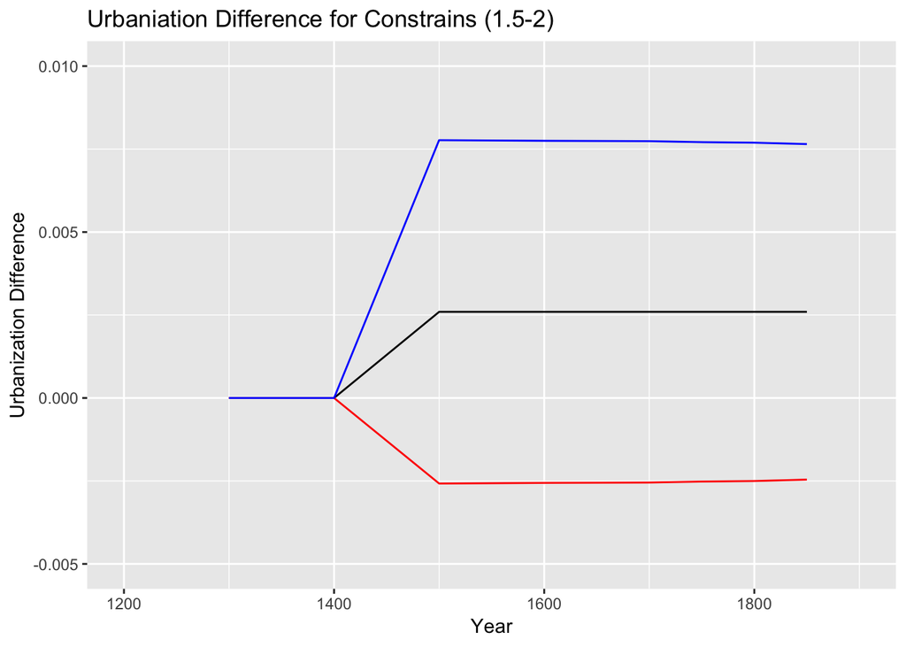

```r
# Data setup for two identical countries with different initial constrains
italy_fr <- filter(datos, country=='Italy')
italy_fr$initialConstr <- 1.5
italy_sc <- filter(datos, country=='Italy')
italy_sc$initialConstr <- 2

# Model calculation
ita_fr <- data.frame(predict(f_model, italy_fr, interval = "confidence"))
ita_sc <- data.frame(predict(f_model, italy_sc, interval = "confidence"))
ita_ddf <- data.frame(ita_fr - ita_sc)
ita_ddf <- mutate(ita_ddf, year=italy_fr$year)

# Graph
ggplot() +
  geom_path(data=ita_ddf, aes(x=year, y=fit), color='black') +
  geom_path(data=ita_ddf, aes(x=year, y=lwr), color='red') +
  geom_path(data=ita_ddf, aes(x=year, y=upr), color='blue') +
  ylim(-0.005, 0.01) + xlim(1200, 1900) + ylab("Urbanization Difference") + xlab("Year") + ggtitle("Urbaniation Difference for Constrains (1.5-2)")
```

## Error Analysis

#### Model and Actual Values

To gather the performance of the model, a useful step is to check how the predicted value from the model relates to the actual values. A plot fitted/predicted values of urbanization for each data point against the actual values shows a linear pattern that goes straight to the origin.

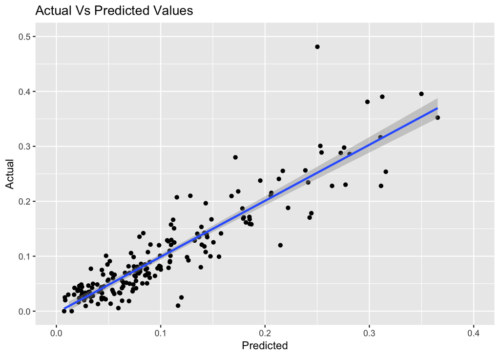

```r
# Data Cleaning
countries_out_fit = c("India", "Japan", "China", "Turkey")
for (coun in countries_out_fit) {
  datos <- filter(datos, country != coun)
}

# Modeling data set
mod <- data.frame(predict(f_model, datos, interval = "predict"))
datos <- mutate(datos, urb_predicted = mod$fit)

# Graph of Actual vs Predicted urbanization index
ggplot(datos) + aes(x = urb_predicted, y = urbanization) + geom_point() + ylim(0, 0.5) + xlim(0, 0.4) + ylab("Actual") + xlab("Predicted") + ggtitle("Actual Vs Predicted Values") + stat_smooth(method = "lm")
```

#### Residuals

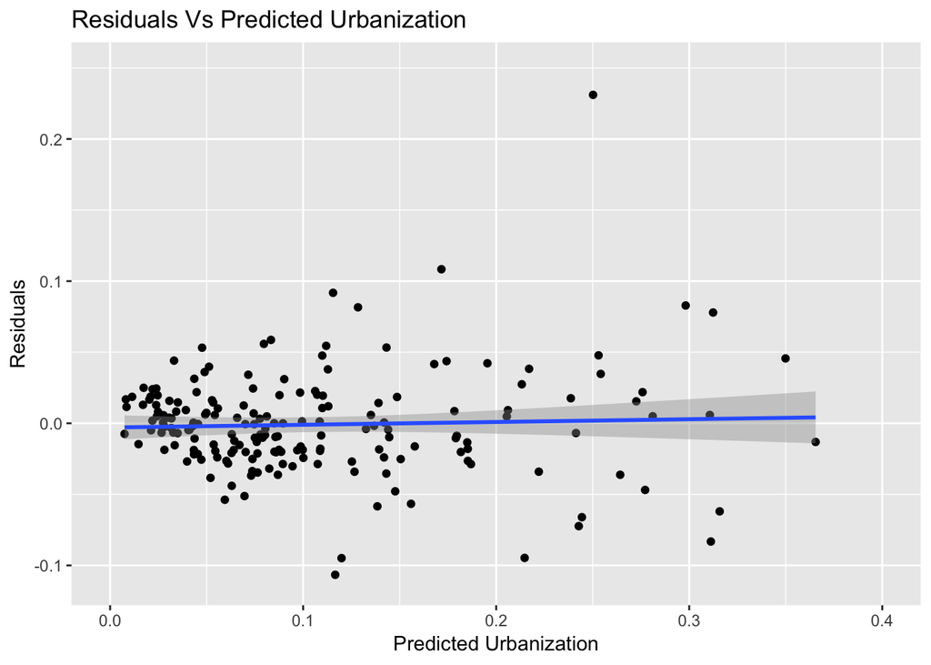

```r
datos <- mutate(datos, residual = datos$urbanization-datos$urb_predicted)
datos <- mutate(datos, resid_sq = residual^2)

ggplot(datos) + aes(x = urb_predicted, y = residual) + geom_point() + ylim(-0.11, 0.25) + xlim(0, 0.4) + ylab("Residuals") + xlab("Predicted Urbanization") + ggtitle("Residuals Vs Predicted Urbanization") + stat_smooth(method= 'lm')
```

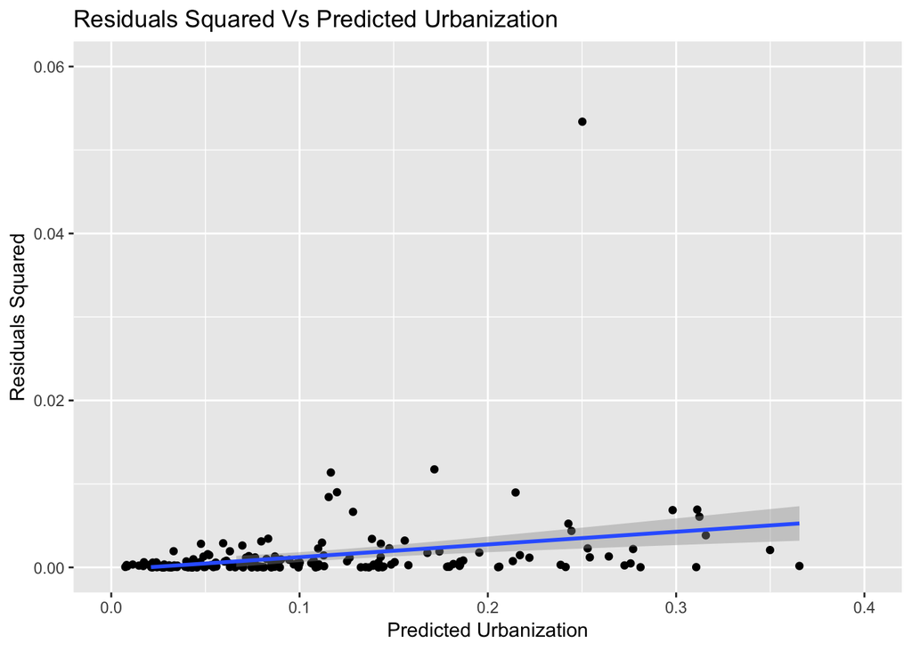

```r
ggplot(datos) + aes(x = urb_predicted, y = resid_sq) + geom_point() + ylim(0, 0.06) + xlim(0, 0.4) + ylab("Residuals Squared") + xlab("Predicted Urbanization") + ggtitle("Residuals Squared Vs Predicted Urbanization") + stat_smooth(method = 'lm')
```

#### Distribution of Residuals

To verify the certainty and the maginitude of the errors from the model, statistical analysis showed the model can provide a close approximation to the actual values.

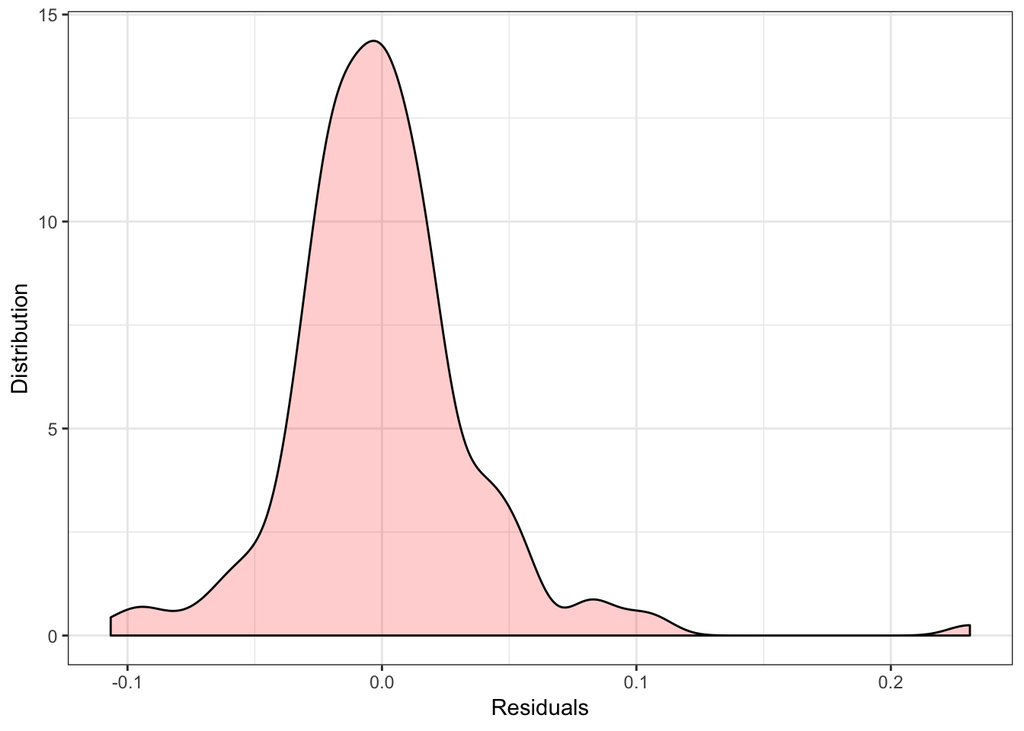

```r
# Distribution of residuals
ggplot(datos, aes(x = residual)) + ylab("Distribution") + xlab("Residuals") +
  geom_density(colour='black', fill='red', alpha=0.2) + theme_bw()
```

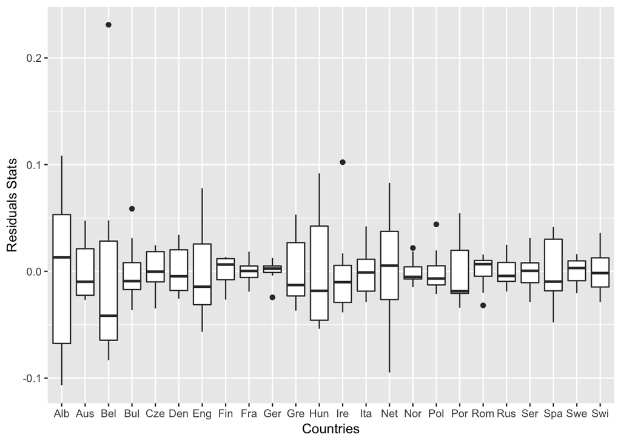

```r
# Boxplot of residuals by country
datos <- mutate(datos, country_ini = substr(datos$country, 1, 3))

ggplot(datos, aes(x=country_ini, y=residual)) + geom_boxplot() + ylab("Residuals Stats") + xlab("Countries")
```

Distribution of residuals seems to be narrowed and normally distributed expected to be close to zero. While the box plot of the distribution of residuals by country shows that each country have different residual distribution.